# R Notebook

# Crimes in Chicago - Differences across years 2006 and 2016

#### Aims

[interactive chart not shown]

The number of crimes peaked in 2003 (470,958 crimes) then decreased since 2005. I would like to investigate the differences in crime across years, namely the percent increase or decrease in crime and the possible reasons that account for changes given the data. Here is the percent change between each year.

[interactive chart not shown]

Since 2006, the crime percent change from previous years has decreased. There are large swings in early years. The number of crimes increased from 2002 to 2003 by 27% (bar at the ‘2003’ x-axis label). It decreased by 22% from 2003 and 2004, then increased by 14% from 2004 to 2005. What accounts for these swings? I suspect it is due to data entry/record keeping as opposed to a dramatic change in crime in early 2000s. I discuss this at the end - see “Crime from 2002 to 2004”.

Let’s look at specific crime types starting with theft.

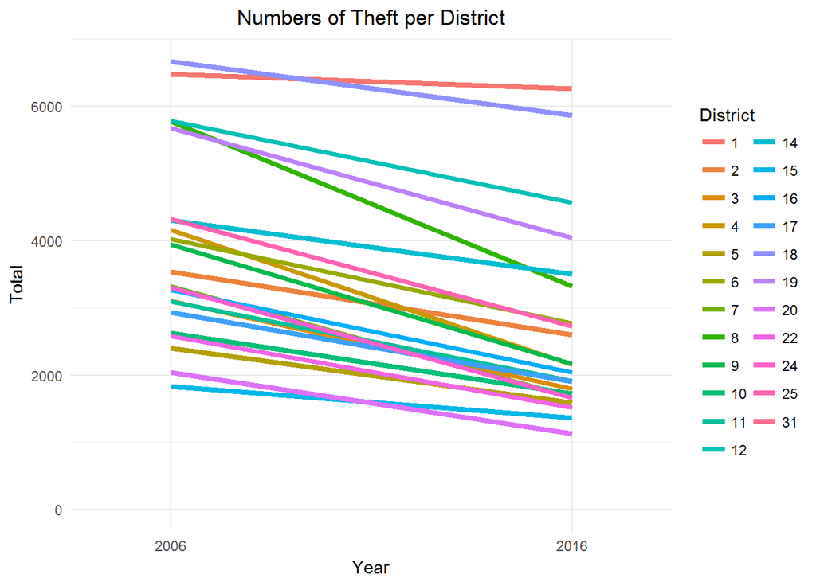

Essentially all Districts experienced a decrease in theft. The table below shows the percent decreased in crime per District.

```
## # A tibble: 23 × 4
##    District `2006` `2016` `Percent Change`
##       <dbl>  <int>  <int>            <dbl>
## 1         7   3324   1672              -99
## 2        24   3304   1665              -98
## 3         4   4159   2158              -93
## 4         9   3942   2170              -82
## 5        20   2043   1129              -81
## 6         8   5775   3319              -74
## 7         3   3109   1795              -73
## 8        22   2579   1522              -69
## 9        11   3095   1919              -61
## 10       16   3270   2039              -60
## # ... with 13 more rows
```

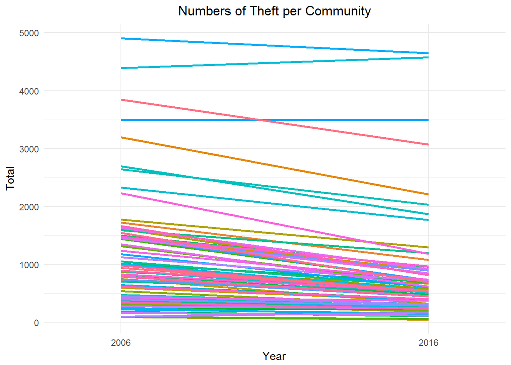

Not all Community Areas experienced a drop in theft. The table below shows that Avalon Park had the greatest decrease in theft (154%). Oakland experiences a 41 % increased in theft. In Oakland’s defence, I do not have the population numbers in 2006 and 2016. Perhaps there was a significant increase in the residence of Oaklands that accounts for part of the increase in theft.

```
## # A tibble: 77 × 4
##    `Community Area` `2006` `2016` `Percent Change`
##               <chr>  <int>  <int>            <dbl>
## 1       AVALON PARK    467    184             -154
## 2     BRIGHTON PARK    753    324             -132
## 3        WEST RIDGE   1549    694             -123
## 4     SOUTH CHICAGO   1349    617             -119
## 5    WEST ENGLEWOOD   1666    815             -104
## 6          BURNSIDE     95     47             -102
## 7          NEW CITY   1475    730             -102
## 8         MONTCLARE    252    127              -98
## 9         ENGLEWOOD   1444    733              -97
## 10     CHICAGO LAWN   1610    829              -94
## # ... with 67 more rows
```

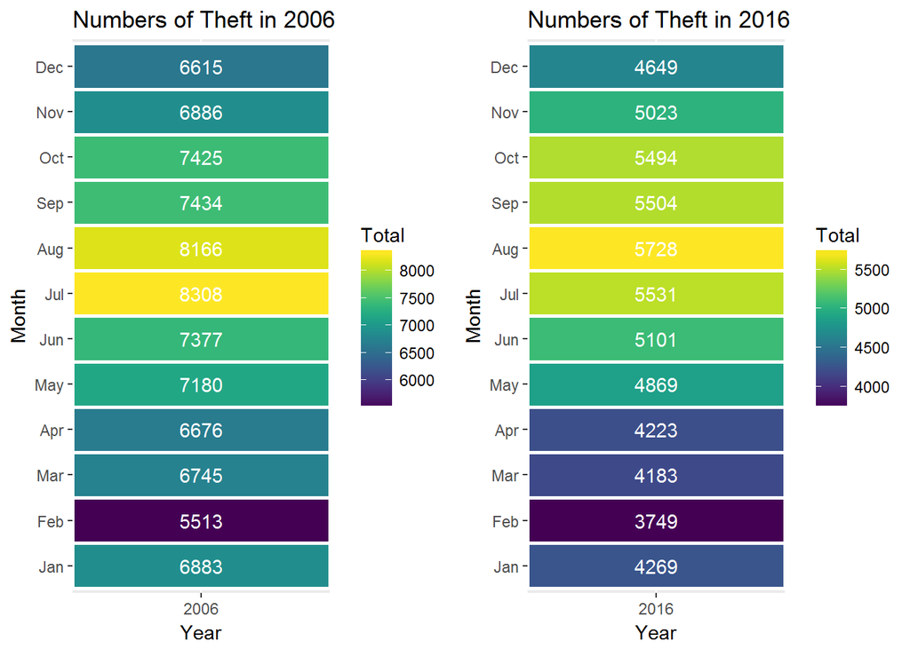

The numbers of theft are proportional across the months over both years. The summer months are a time for theft in Chicago.

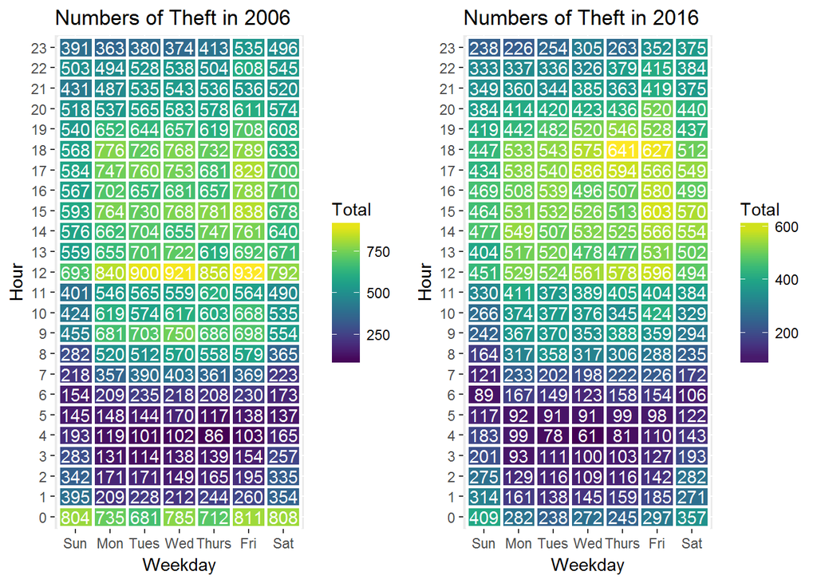

Again, theft is proportional across both years per weekday and hour. There does appear to be a theft hotspot around weekdays at noon during 2006 (possible because residents are at work, leaving homes vacant). In 2016, the hotspots are on Thursday and Fridays at 6 pm.